# **Programación dinámica**

En informática, la programación dinámica es un método para reducir el tiempo de ejecución de un algoritmo mediante la utilización de subproblemas superpuestos y subestructuras óptimas.

Richard Bellman inventó la programación dinámica en 1953 que se utiliza para optimizar problemas complejos que pueden ser discretizados y secuencializados.

## Subestructura óptima

Una **subestructura óptima** significa que se pueden usar soluciones óptimas de subproblemas para encontrar la solución óptima del problema en su conjunto.

Los subproblemas se resuelven a su vez dividiéndolos en subproblemas más pequeños hasta que se alcance el caso fácil, donde la solución al problema es trivial.

Decir que un problema tiene subproblemas superpuestos es decir que se usa un mismo subproblema para resolver diferentes problemas mayores. Por ejemplo, en la sucesión de Fibonacci (F3 = F1 + F2 y F4 = F2 + F3) calcular cada término supone calcular F2. Como para calcular F5 hacen falta tanto F3 como F4, una mala implementación para calcular F5 acabará calculando F2 dos o más veces. Esto sucede siempre que haya subproblemas superpuestos: una mala implementación puede acabar desperdiciando tiempo recalculando las soluciones óptimas a problemas que ya han sido resueltos anteriormente.

Esto se puede evitar guardando las soluciones que ya hemos calculado. Entonces, si necesitamos resolver el mismo problema más tarde, podemos obtener la solución de la lista de soluciones calculadas y reutilizarla. Este acercamiento al problema se llama memoización (no confundir con memorización; en inglés es llamado memoization, véase en). Si estamos seguros de que no volveremos a necesitar una solución en concreto, la podemos descartar para ahorrar espacio. En algunos casos, podemos calcular las soluciones a problemas que de antemano sabemos que vamos a necesitar.

En resumen, la programación hace uso de:

- Subproblemas superpuestos
- Subestructuras óptimas
- Memoización

## Definiciones

1. La programación dinámica es un método cuantitativo
2. Desarrollado por Richard Bellman
3. La programación dinámica es una “optimización de procesos con etapa múltiples”
4. Consiste en descomponer el problema en subproblemas (más manejables)

### Tipos de enfoque

- Existen dos tipos de programación dinámica: La programación Dinámica determinística se utilizan datos que se conocen con certeza y la programación dinámica probabilística donde se usan datos que no se conocen con certeza pero que se determinan a través de distribuciones de probabilidad.

## Ejemplos

**Sucesión de Fibonacci**

Esta sucesión puede expresarse mediante la siguiente recurrencia:

\begin{equation} \text{Fib}(n) = \begin{cases} 0 & \text{si } n = 0 \\ 1 & \text{si } n = 1 \\ \text{Fib}(n - 1) + \text{Fib}(n - 2) & \text{si } n > 1 \end{cases} \end{equation}

Una implementación de una función que encuentre el n-ésimo término de la sucesión de Fibonacci basada directamente en la definición matemática de la sucesión realizando llamadas recursivas hace mucho trabajo redundante, obteniéndose una complejidad exponencial:

**FUNC fib(↓n: NATURAL): NATURAL**

**INICIO**

- **SI** n = 0 **ENTONCES**
  - DEVOLVER 0
- **SI NO, SI** n = 1 **ENTONCES**
  - DEVOLVER 1
- **SI NO**
  - DEVOLVER fib(n-1) + fib(n-2)

**FIN SI**

**FIN**

Si llamamos, por ejemplo, a fib(5), produciremos un árbol de llamadas que contendrá funciones con los mismos parámetros varias veces:

- fib(5)
- fib(4) + fib(3)
- (fib(3) + fib(2)) + (fib(2) + fib(1))
- ((fib(2) + fib(1)) + (fib(1) + fib(0))) + ((fib(1) + fib(0)) + fib(1))
- (((fib(1) + fib(0)) + fib(1)) + (fib(1) + fib(0))) + ((fib(1) + fib(0)) + fib(1))

En particular, fib(2) se ha calculado tres veces desde cero. En ejemplos mayores, se recalculan muchos otros valores de fib, o subproblemas.

Para evitar este inconveniente, podemos resolver el problema mediante programación dinámica, y en particular, utilizando el enfoque de memoización (guardar los valores que ya han sido calculados para utilizarlos posteriormente). Así, rellenaríamos una tabla con los resultados de los distintos subproblemas, para reutilizarlos cuando haga falta en lugar de volver a calcularlos. La tabla resultante sería una tabla unidimensional con los resultados desde 0 hasta n.

**FUNC Fibonacci(↓n: NATURAL): NATURAL**  
**VARIABLES**

- tabla: ARRAY [0..n] DE NATURALES
- i: NATURAL

**INICIO**

- tabla[0] := 0
- tabla[1] := 1
- **PARA** i = 2 **HASTA** n **HACER**
  - tabla[i] := tabla[i-1] + tabla[i-2]
- **FIN PARA**
- DEVOLVER tabla[n]

**FIN**

La función resultante tiene complejidad O(n), en lugar de 2 a la n (puesto que genera un árbol binario en memoria, donde el último nivel de hojas es de la forma 2 a la n). En otras palabras, la programación dinámica, en este caso, permite disminuir la complejidad computacional del algoritmo.

# Actividad en clases:

**Objetivo:** Comprender y comparar la eficiencia de la función Fibonacci implementada con programación dinámica y recursividad.

**Instrucciones:**

1. Desarrolle el código de la función Fibonacci utilizando dos enfoques:
   - Programación dinámica: Aproveche la técnica de memoización o el uso de arreglos para evitar cálculos redundantes.
   - Recursividad simple: Implemente la función basándose directamente en su definición matemática, sin técnicas de optimización.
2. Una vez que tenga ambos códigos implementados, proceda a medir y registrar el tiempo de ejecución para diversos valores de `n`.
3. Realice una gráfica que cumpla con las siguientes características:
   - Eje X: Valor de `n` ingresado.
   - Eje Y: Tiempo de ejecución en segundos.
   - Utilice colores distintos para representar cada una de las implementaciones. Asegúrese de incluir una leyenda en la gráfica que indique qué color corresponde a cada función (programación dinámica o recursividad).
4. Analice y reflexione sobre los resultados obtenidos. ¿Qué puede concluir sobre la eficiencia de cada enfoque? ¿En qué situaciones sería preferible usar uno sobre el otro?

**Recomendación**: Haga uso de bibliotecas como matplotlib o seaborn para la creación de la gráfica en Python.

**Resultado esperado**

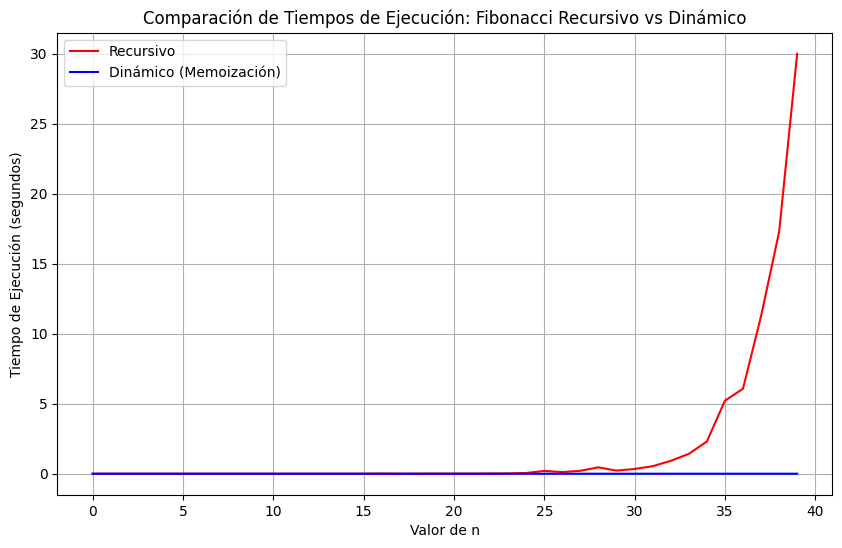

## Actividad: Problema de la Moneda (Coin Change)

Definición:

Supongamos que estás en un país con un sistema monetario peculiar. Las denominaciones de las monedas no son las habituales y te enfrentas a la tarea de hacer cambio para una cantidad específica.

El problema es el siguiente: Dado un conjunto de monedas con diferentes denominaciones y una cantidad total, encuentre el número mínimo de monedas que suman esa cantidad. Si no es posible hacer la cantidad con las monedas dadas, devuelve -1.

**Ejemplo:** Si las monedas son [1, 2, 5] y la cantidad es 11, la respuesta es 3 porque 11 = 5 + 5 + 1.

**Solución Recursiva:**

```python
def coinChange(coins, amount):
    # Función recursiva para calcular la cantidad mínima de monedas
    def helper(coins, amount, memo):
        if amount < 0:
            return -1
        if amount == 0:
            return 0
        if amount in memo:
            return memo[amount]

        min_coins = float('inf')
        for coin in coins:
            res = helper(coins, amount - coin, memo)
            if res >= 0:
                min_coins = min(min_coins, res + 1)

        memo[amount] = -1 if min_coins == float('inf') else min_coins
        return memo[amount]

    return helper(coins, amount, {})
coinChange([1,2,5], 11)
```

```
3
```

**Solución de Programación Dinámica:**

Usamos programación dinámica para evitar la reevaluación de los resultados. La idea es construir una tabla dp donde dp[i] representará el número mínimo de monedas requeridas para la cantidad i.

**Desarrolle el código:** ...

**Actividad: Problema de la Subsecuencia de Suma Máxima (Maximal Subarray Problem)**

**Definición y Contexto:**

Imagina que estás evaluando la rentabilidad diaria de las acciones en la bolsa de valores durante un período específico. Cada valor representa la ganancia o pérdida de un día en particular. Si un valor es positivo, eso significa que ese día hubo una ganancia, y si es negativo, hubo una pérdida. Tu tarea es identificar un período (que puede ser de un solo día o de varios días seguidos) en el cual hayas obtenido la máxima ganancia.

Dada una secuencia de números, que representan la rentabilidad diaria, debes encontrar la subsecuencia continua (es decir, días consecutivos) que tenga la suma más grande.

**Ejemplo:** Para la secuencia [-2, 1, -3, 4, -1, 2, 1, -5, 4], puedes pensar en ella como la rentabilidad diaria de 9 días consecutivos. En este caso, los días con la rentabilidad más alta cuando se consideran juntos son del cuarto al séptimo día, con una rentabilidad total de 6.

**Solución Recursiva:**

```python
def max_crossing_sum(arr, l, m, h):
    # Incluye elementos a la izquierda de mid
    sm = 0
    left_sum = float('-inf')

    for i in range(m, l-1, -1):
        sm += arr[i]
        if sm > left_sum:
            left_sum = sm

    # Incluye elementos a la derecha de mid
    sm = 0
    right_sum = float('-inf')
    for i in range(m + 1, h + 1):
        sm += arr[i]
        if sm > right_sum:
            right_sum = sm

    return left_sum + right_sum

def max_subarray_sum_rec(arr, l, h):
    # Caso base: Solo un elemento
    if l == h:
        return arr[l]

    m = (l + h) // 2

    # Retorna el máximo de 3 valores:
    # 1. Máxima suma en la subsecuencia izquierda (divide y vencerás)
    # 2. Máxima suma en la subsecuencia derecha (divide y vencerás)
    # 3. Máxima suma en la subsecuencia que cruza el punto medio
    return max(max_subarray_sum_rec(arr, l, m),
               max_subarray_sum_rec(arr, m+1, h),
               max_crossing_sum(arr, l, m, h))

def maximal_subarray_recursive(arr):
    return max_subarray_sum_rec(arr, 0, len(arr) - 1)

maximal_subarray_recursive([-2, 1, -3, 4, -1, 2, 1, -5, 4])
```

```
6
```

Solución de Programación Dinámica (Algoritmo de Kadane)

Desarrolle...